# Rational metacognition in memory (all trials)

# Results

## Probability of remembering first word

As a sanity check, we first ask if our memory strength index predicts participants choices about which image to recall. We operationalize memory strength as the within-participant Z-scored, mean log 2AFC RT (that’s a mouthful!) If this index tracks memory strength, we should see that the probability that a target is chosen for recollection should depend on the difference in “strength” between the two cues.

Note: For the model, strength corresponds to the $p$ parameter. Here, we simply Z-score $p$ to put it in roughly the same units. The assumption that $p$ is linearly related to log reaction time is almost certainly wrong, but it’s enough to get a sense of qualitative model predictions.

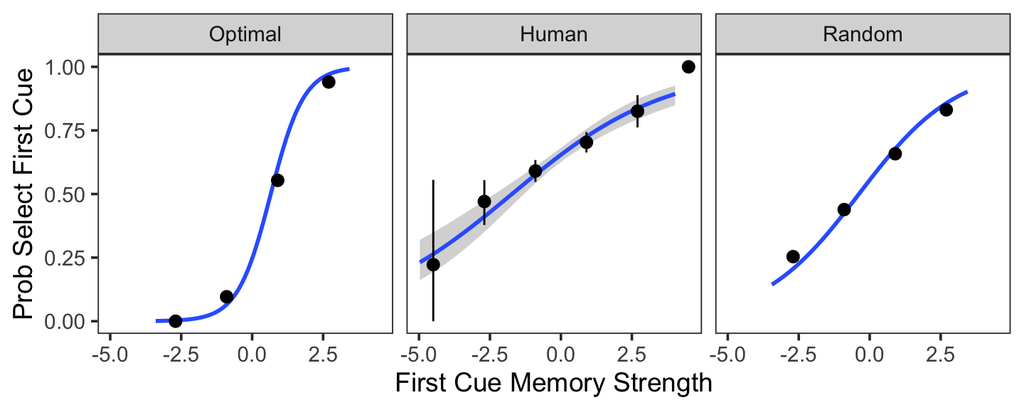

```r
df %>%
    ggplot(aes(rel_strength, as.numeric(choose_first))) +
    geom_smooth(method = "glm", method.args = list(family = "binomial"), formula=y~x) +
    stat_summary_bin(fun.data=mean_cl_boot, bins=5) +
    facet_wrap(~name) +
    labs(x="First Cue Memory Strength", y="Prob Select First Cue")
```

```r
X = df %>% filter(name == "Human")
lmer(choose_first ~ rel_strength + (rel_strength|wid), data=X) %>% summ
```

| Fixed Effects | Fixed Effects Est. | Fixed Effects S.E. | Fixed Effects t val. | Fixed Effects d.f. | Fixed Effects p |
| --- | --- | --- | --- | --- | --- |
| (Intercept) | 0.646 | 0.022 | 29.092 | 65.713 | 0.000 |
| rel_strength | 0.080 | 0.010 | 7.687 | 64.305 | 0.000 |

p values calculated using Satterthwaite d.f.

```r
# lmer(choose_first ~ strength_first + strength_second + (strength_first + strength_second |wid), data=X) %>% summ
```

Note: unless otherwise stated, all regression tables are maximal linear mixed effects models (random slopes and intercepts) applied to the human data. Plotted regression lines are fixed effects only.

## Fixation proportion by relative memory strength

The simplest test of rational memory: do people spend more time looking at the cue that they have a stronger memory of? This analysis only considers trials where both cues are seen.

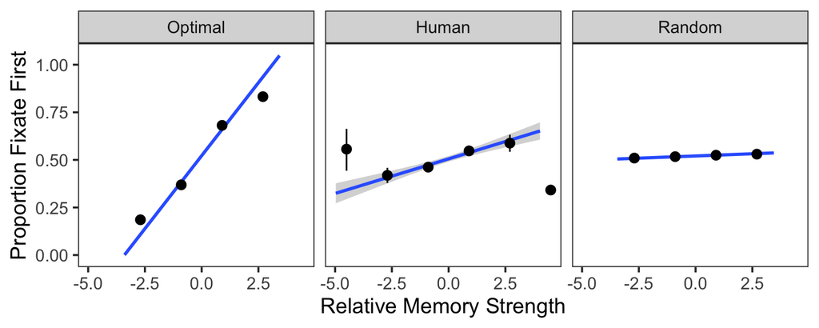

```r
df %>%
    filter(n_pres >= 2) %>%
    ggplot(aes(rel_strength, prop_first)) +
    geom_smooth(method = "lm", formula="y~x") +
    stat_summary_bin(fun.data=mean_cl_boot, bins=5) +
    facet_wrap(~name) +
    labs(x="Relative Memory Strength", y="Proportion Fixate First")
```

```r
X = df %>% filter(n_pres >= 2 & name == "Human")
lmer(choose_first ~ rel_strength + (rel_strength|wid), data=X) %>% summ
```

| Fixed Effects | Fixed Effects Est. | Fixed Effects S.E. | Fixed Effects t val. | Fixed Effects d.f. | Fixed Effects p |
| --- | --- | --- | --- | --- | --- |
| (Intercept) | 0.416 | 0.023 | 17.967 | 42.445 | 0.000 |
| rel_strength | 0.096 | 0.013 | 7.372 | 77.050 | 0.000 |

p values calculated using Satterthwaite d.f.

They do! 🎉

But hold on, what’s going on with the random model…

### Last fixation effect

People remember the thing they look at last 94% of the time. In value-based decision making, it has been suggested that this last-fixation effect could explain away what looks to be evidence for adaptive attention allocation. This claim did not hold up there, but it could nevertheless be affecting our results.

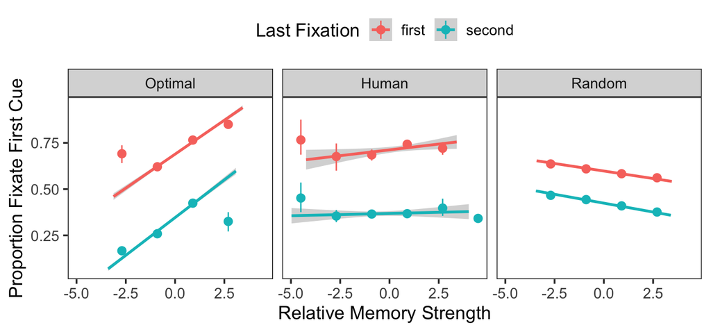

```r
df %>%
    filter(n_pres >= 2) %>%
    ggplot(aes(rel_strength, prop_first, color=last_pres)) +
    geom_smooth(method="lm") +
    stat_summary_bin(fun.data=mean_cl_boot, bins=5) +
    facet_wrap(~name) +
    theme(legend.position="top") +
    labs(x="Relative Memory Strength", y="Proportion Fixate First Cue", color="Last Fixation")
```

```r
X = df %>% filter(n_pres > 1 & name == "Human")
lmer(prop_first ~ rel_strength * last_pres + (rel_strength * last_pres | wid), data=X) %>% summ
```

| Fixed Effects | Fixed Effects Est. | Fixed Effects S.E. | Fixed Effects t val. | Fixed Effects d.f. | Fixed Effects p |
| --- | --- | --- | --- | --- | --- |
| (Intercept) | 0.709 | 0.012 | 60.922 | 48.144 | 0.000 |
| rel_strength | 0.009 | 0.005 | 1.680 | 72.414 | 0.097 |
| last_pressecond | -0.335 | 0.018 | -18.698 | 46.039 | 0.000 |
| rel_strength:last_pressecond | -0.006 | 0.007 | -0.840 | 409.405 | 0.402 |

p values calculated using Satterthwaite d.f.

Indeed, the effect of relative memory strength on fixation proportion (nearly?) disappears when we control for the effect of the last fixation. Read on for an explanation, but **feel free to skip to the next section**.

What’s going on here? Basically it is due to the last fixation being correlated with both fixation proportion and relative strength. The first item is fixated longer on trials where the first cue is seen last (because it has one more fixation than the other cue).

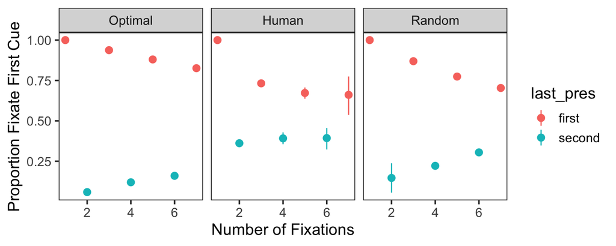

```r
df %>%
    filter(n_pres < 8) %>%
    ggplot(aes(n_pres, prop_first, color=last_pres)) +
    facet_wrap(~name) +
    labs(x='Number of Fixations', y='Proportion Fixate First Cue') +
    stat_summary(fun.data=mean_cl_boot)
```

Furthermore, relative strength is higher for trials where the last fixation is on the first item. This is (presumably) because people tend to remember the cue they look at last and they are also more likely to remember the stronger pair.

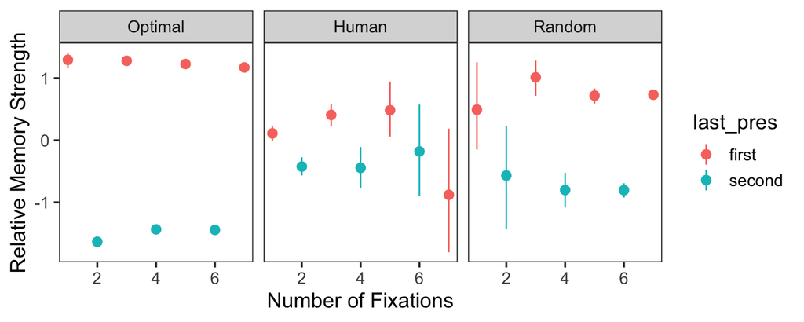

```r
df %>%
    filter(n_pres < 8) %>%
    ggplot(aes(n_pres, rel_strength, color=last_pres)) +
    facet_wrap(~name) +
    labs(x="Number of Fixations", y="Relative Memory Strength") +
    stat_summary(fun.data=mean_cl_boot)
```

Putting the last two effects together, we get a correlation between strength and fixation proportion based only on the target of the last fixation.

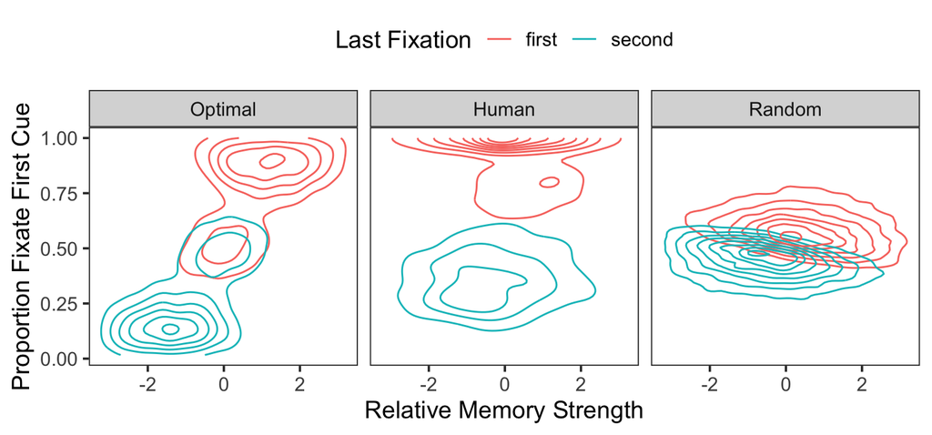

```r
df %>%
    ggplot(aes(rel_strength, prop_first, color=last_pres)) +
    # geom_point() +
    # geom_errorbar(aes(ymin=prop_first_mean - prop_first_sd, ymax=prop_first_mean + prop_first_sd)) +
    # geom_errorbarh(aes(xmin=rel_strength_mean - rel_strength_sd, xmax=rel_strength_mean + rel_strength_sd)) +
    geom_density_2d() +
    facet_wrap(~name) +
    theme(legend.position="top") +
    labs(x="Relative Memory Strength", y="Proportion Fixate First Cue", color="Last Fixation")
```

It might be easier to see if we group the data by number of fixations:

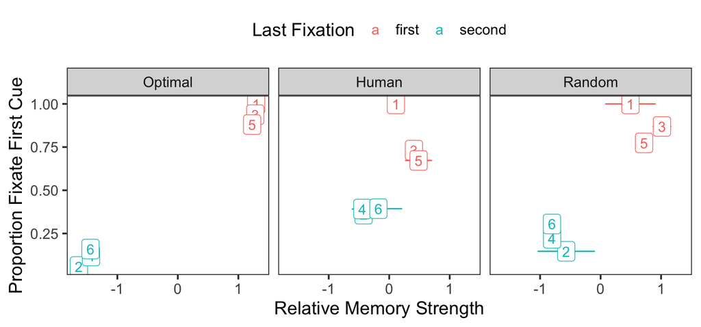

```r
df %>%
    filter(between(n_pres, 1, 6)) %>%
    group_by(name, last_pres, n_pres) %>%
    summarise(across(c(rel_strength, prop_first), list(mean=mean, sd=~ sd(.x) / sqrt(length(.x))))) %>%
    ggplot(aes(rel_strength_mean, prop_first_mean, color=last_pres, label=n_pres)) +
    geom_errorbar(aes(ymin=prop_first_mean - prop_first_sd, ymax=prop_first_mean + prop_first_sd)) +
    geom_errorbarh(aes(xmin=rel_strength_mean - rel_strength_sd, xmax=rel_strength_mean + rel_strength_sd)) +
    facet_wrap(~name) +
    theme(legend.position="top") +
    labs(x="Relative Memory Strength", y="Proportion Fixate First Cue", color="Last Fixation") +
    geom_label()
```

## First fixation duration

Given the complications with the total fixation duration, the duration of the first fixation is potentially a more reliable cue. The model makes a strong prediction here, and it probably isn’t confounded by the last fixation effect.

Consider only the trials with more than one fixation. Do participants switch away from the first image more quickly when they have a worse memory of it?

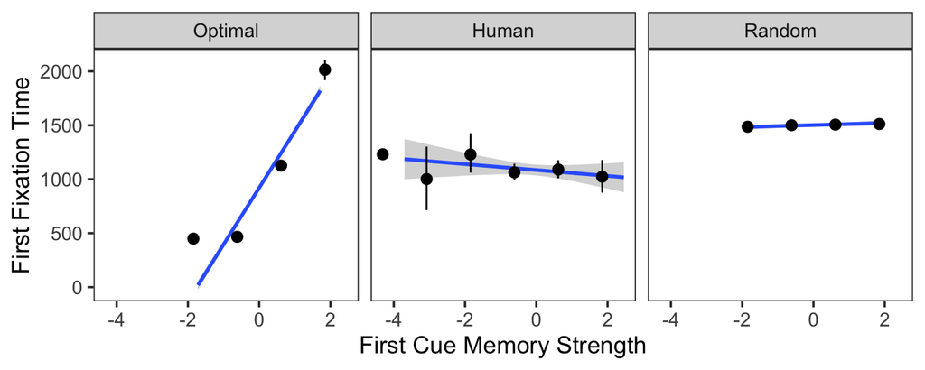

```r
df %>%
    filter(n_pres >= 2) %>%
    ggplot(aes(strength_first, first_pres_time)) +
    geom_smooth(method="lm") +
    stat_summary_bin(fun.data=mean_cl_boot, bins=5) +
    facet_wrap(~name) +
    labs(x="First Cue Memory Strength", y="First Fixation Time")
```

```r
human %>%
    filter(n_pres >= 2) %>%
    lmer(first_pres_time ~ strength_first + (strength_first|wid), data=.) %>% summ
```

| Fixed Effects | Fixed Effects Est. | Fixed Effects S.E. | Fixed Effects t val. | Fixed Effects d.f. | Fixed Effects p |
| --- | --- | --- | --- | --- | --- |
| (Intercept) | 1309.409 | 89.287 | 14.665 | 44.387 | 0.000 |
| strength_first | 37.163 | 24.354 | 1.526 | 28.851 | 0.138 |

p values calculated using Satterthwaite d.f.

No sign of an effect here.

## Second fixation duration

We can do a similar analysis for the second fixation duration. In this case, however, the duration may depend on the strength of both the first and second cues. As before, we exclude final fixations in this plot (i.e. excluding trials less than three fixations).

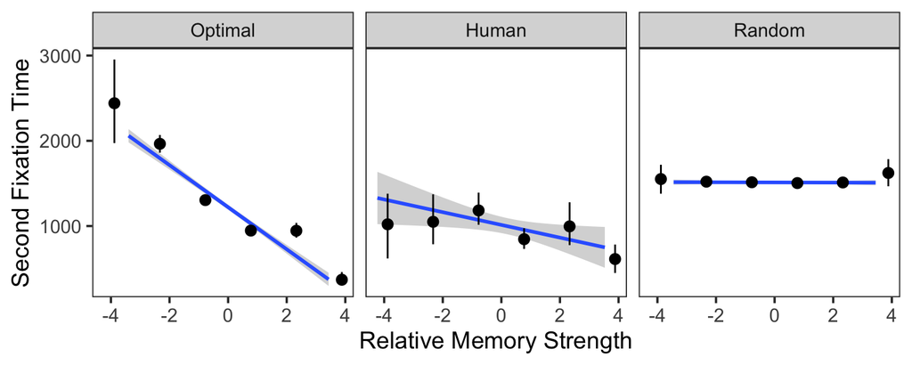

```r
df %>%
    filter(n_pres >= 3) %>%
    ggplot(aes(rel_strength, second_pres_time)) +
    geom_smooth(method="lm") +
    stat_summary_bin(fun.data=mean_cl_boot, bins=5) +
    facet_wrap(~name) +
    labs(x="Relative Memory Strength", y="Second Fixation Time")
```

```r
X = human %>%
     filter(n_pres >= 3)

X %>% lmer(second_pres_time ~ rel_strength + (rel_strength|wid), data=.) %>% summ
```

| Fixed Effects | Fixed Effects Est. | Fixed Effects S.E. | Fixed Effects t val. | Fixed Effects d.f. | Fixed Effects p |
| --- | --- | --- | --- | --- | --- |
| (Intercept) | 1116.328 | 95.010 | 11.750 | 43.342 | 0.000 |
| rel_strength | -69.369 | 32.506 | -2.134 | 30.950 | 0.041 |

p values calculated using Satterthwaite d.f.

```r
# X %>% lmer(second_pres_time ~ strength_first + strength_second + (strength_first + strength_second|wid), data=.) %>% summ
```

Look at that, a significant effect!

## Third fixation duration

Same thing for the third fixation.

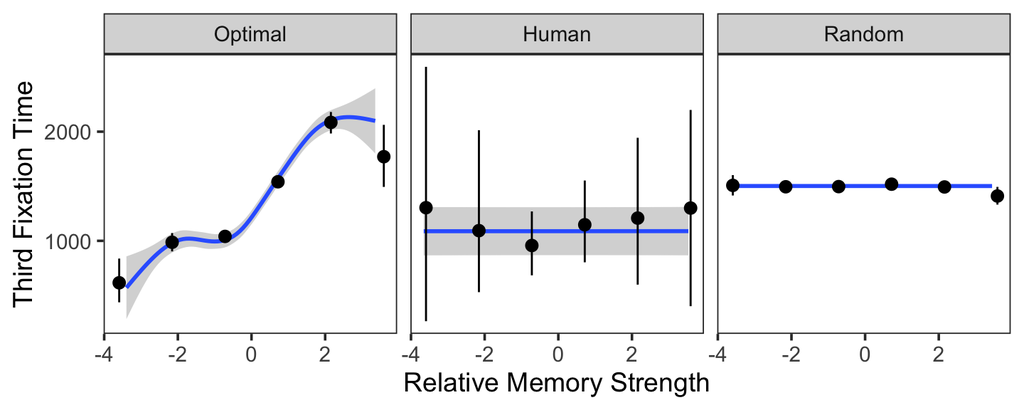

```r
df %>%
    filter(n_pres >= 4) %>%
    ggplot(aes(rel_strength, third_pres_time)) +
    geom_smooth() +
    stat_summary_bin(fun.data=mean_cl_boot, bins=5) +
    facet_wrap(~name) +
    labs(x="Relative Memory Strength", y="Third Fixation Time")
```

```r
human %>%
    filter(n_pres >= 4) %>%
    lmer(third_pres_time ~ rel_strength + (rel_strength|wid), data=.) %>% summ
```

| Fixed Effects | Fixed Effects Est. | Fixed Effects S.E. | Fixed Effects t val. | Fixed Effects d.f. | Fixed Effects p |
| --- | --- | --- | --- | --- | --- |
| (Intercept) | 1375.986 | 285.480 | 4.820 | 26.751 | 0.000 |
| rel_strength | 100.099 | 78.147 | 1.281 | 9.176 | 0.232 |

p values calculated using Satterthwaite d.f.

Nice.

## Time course

Finally, we can make a plot similar to the initial model prediction. How does the probability of fixating the more-memorable option change over the course of the trial? We normalize the x axis by the duration of the trial to reduce noise (it’s really messy with raw time).

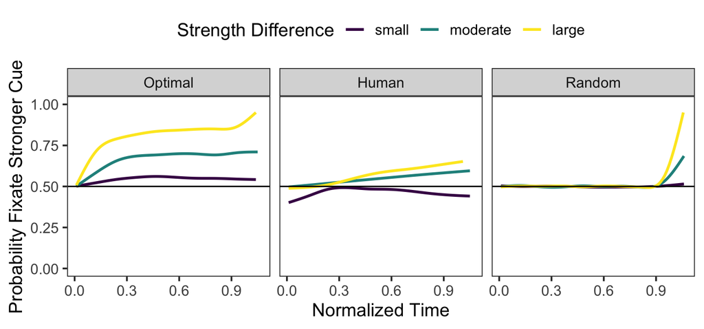

```r
make_fixations = function(df) {
    df %>%
        filter(n_pres >= 1) %>%
        ungroup() %>%
        mutate(
            strength_diff = cut(abs(rel_strength),
                                quantile(abs(rel_strength), c(0, 0.2, 0.6, 1),  na.rm = T),
                                labels=c("small", "moderate", "large"),
                                ordered=T)
        ) %>%
        mutate(trial = row_number()) %>%
        unnest_longer(presentation_times, "duration", indices_to="presentation") %>%
        mutate(
            fix_first = presentation %% 2,
            fix_stronger = as.numeric(fix_first == (rel_strength > 0)),
        )
}

normalized_timestep = function(long) {
    long %>%
        group_by(trial) %>%
        mutate(prop_duration = duration / sum(duration)) %>%
        ungroup() %>%
        mutate(n_step=round(prop_duration * 100)) %>%
        uncount(n_step) %>%
        group_by(trial) %>%
        mutate(normalized_timestep = row_number())
}

long = make_fixations(df)
nts = normalized_timestep(long)
nts %>%
    drop_na(strength_diff) %>%
    ggplot(aes(normalized_timestep/100, fix_stronger, group = strength_diff, color=strength_diff)) +
    geom_smooth(se=F) +
    ylim(0, 1) +
    facet_wrap(~name) +
    labs(x="Normalized Time", y="Probability Fixate Stronger Cue", color="Strength Difference") +
    geom_hline(yintercept=0.5) +
    theme(legend.position="top")
```